# dsx RNA-seq analysis

Sasha Mikheyev

2/16/2018

```r
library(tidyverse)
library(knitr)
library(kableExtra)
library(sleuth)   # gene expression
library(edgeR)    # gene expression
library(qvalue)   # multiple comparisons
library(ggsignif) # significance boxplots
library(scatterD3)# interactive scatterplots
library(networkD3)# interactive networks
library(GOstats)  # GO terms
library(GSEABase) # GO terms
library(devtools) #better session info
library(WGCNA)    # gene co-expression
allowWGCNAThreads()
```

```
## Allowing multi-threading with up to 4 threads.
```

## QC using RSEM data

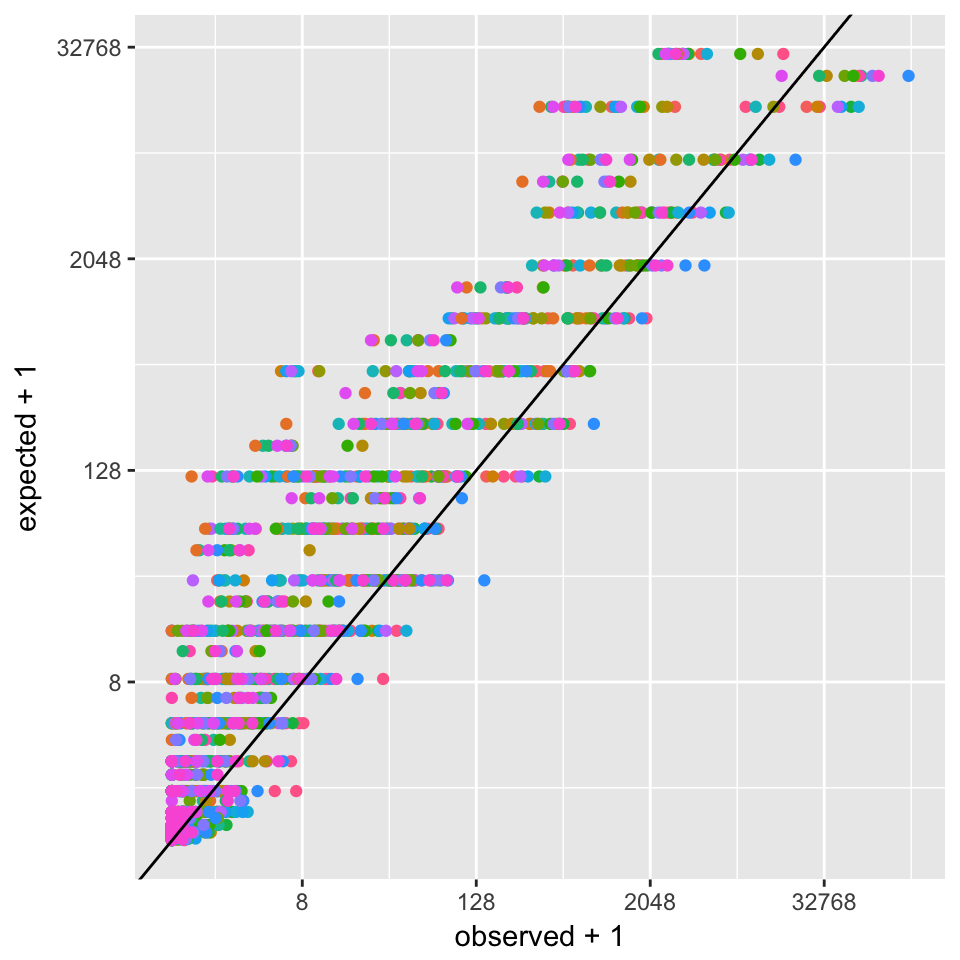

```r
counts <- read_csv("data/genes_counts.csv")
tpm <- read_csv("data/genes_tpm.csv")
treatments <- read_csv("data/treatments.csv", col_types = "ccc")
ercc <- left_join(read_tsv("data/ercc.tsv"), tpm, by = "gene_id")
descriptions <- read_tsv("data/descriptions.tsv", col_names = c("gene_id", "description"))
mix1 <-  ercc[,c("gene_id", "mix1", subset(treatments, spikein == "mix1")$sample)] %>% gather( library, observed, -c(mix1,gene_id)) %>% dplyr::rename(expected = mix1 )
mix2 <- ercc[,c("gene_id", "mix2", as.character(subset(treatments, spikein == "mix2")$sample))] %>% gather( library, observed, -mix2, -gene_id) %>% dplyr::rename(expected = mix2 )
ercc <- rbind(mix1,mix2)
ggplot(ercc, aes(observed+1, expected+1, color=as.factor(library))) + geom_point() + scale_y_continuous(trans='log2')+scale_x_continuous(trans='log2')+ geom_abline()+guides(color=F)
```

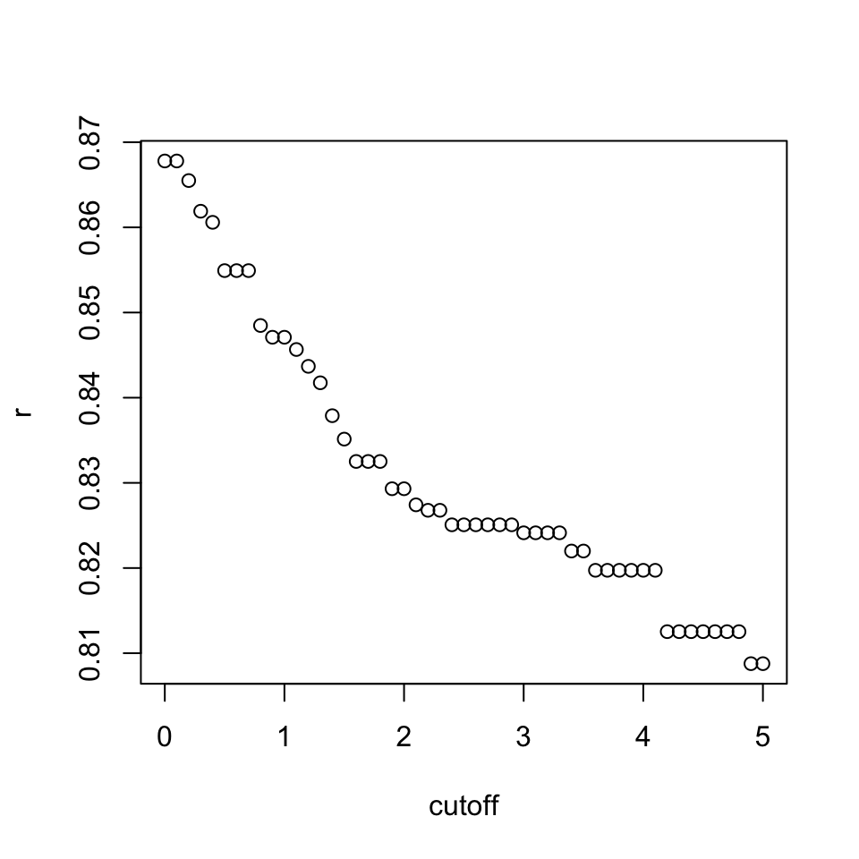

```r
cutoff <- seq(0,5,by=0.1)
r <- c()
for (i in cutoff) {
  keepGenes <- ercc %>% group_by(gene_id, library) %>% summarise(all_mean = mean(observed)) %>% filter(all_mean > i) %>% .$gene_id %>% unique
  r <- c(r, summary(lm(log2(observed+1)~log2(expected+1), data=subset(ercc, gene_id %in% keepGenes)))$r.squared)
}
plot(cutoff,r)
```

The signal to noise is basically fine even at the lowest levels, so we do not do any abundance-based filtering.

## Gene expression analysis

The data are fairly noisy, so we conducted the DGE analysis using two separate alignment/counting philosophies. The more tradional approach uses alignment-based gene quantification using RSEM, and the second one uses a kmer-based approach implemented in Kallisto. Each analysis is shown in a separate tab.

### RSEM/EdgeR analysis

```r
counts <- counts %>% filter(! grepl("ERCC", gene_id))
design <- model.matrix(~treatment, treatments)
cds <- DGEList( counts[,  treatments$sample] , group = treatments$treatment)
dim(cds)
```

```
## [1] 13811    20
```

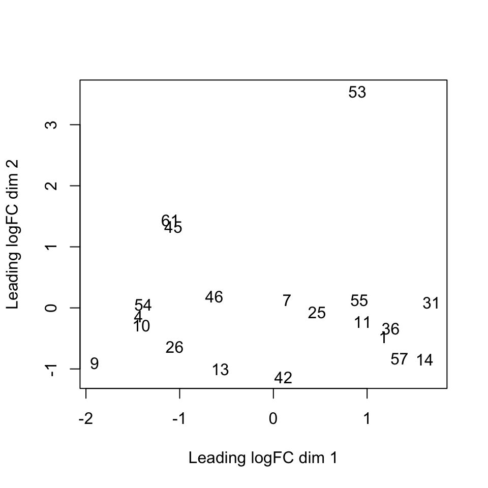

```r
cds <- calcNormFactors( cds)
plotMDS( cds)
```

```r
cds <- estimateDisp( cds, design)
de.tgw <- exactTest( cds , pair = c( "DSX" , "GFP" ) )
de.tgw$table$gene_id <- counts$gene_id
de.tgw$table <- left_join(de.tgw$table, descriptions, by = "gene_id")
de.tgw$table %>% filter(gene_id  == "Dsx")
```

```
##       logFC   logCPM     PValue gene_id description
## 1 0.7612763 6.900205 0.03908283     Dsx   doublesex
```

```r
de.tgw$table %>% filter(gene_id  == "Vg")
```

```
##       logFC  logCPM     PValue gene_id  description
## 1 0.8456437 10.0494 0.01632941      Vg vitellogenin
```

```r
de.tgw$table %>% filter(gene_id  == "Mrjp1")
```

```
##      logFC   logCPM      PValue gene_id                 description
## 1 2.774854 3.957461 0.003626191   Mrjp1 major royal jelly protein 1
```

```r
de.tgw$table %>% filter(gene_id  == "Dnmt3")
```

```
##       logFC   logCPM    PValue gene_id             description
## 1 0.7620547 2.264834 0.0328638   Dnmt3 DNA methyltransferase 3
```

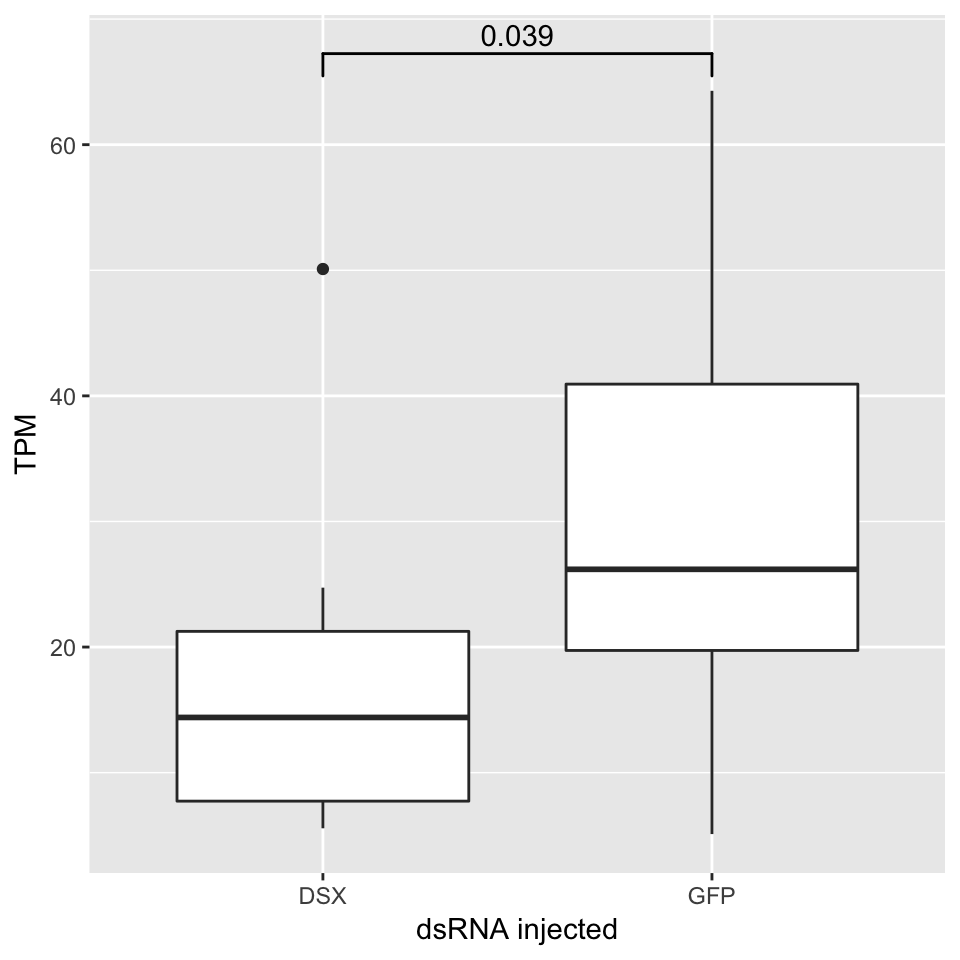

```r
dsxTest <- function(a,b) return(data.frame(p.value = de.tgw$table %>% filter(gene_id  == "Dsx") %>% .$PValue))
data.frame(tpm = t(subset(tpm, gene_id == "Dsx")[,as.character(treatments$sample)]) , trt = treatments$treatment) %>% ggplot(aes(trt,tpm))+geom_boxplot() + geom_signif(comparisons = list(c("DSX", "GFP")), test = "dsxTest") + xlab("dsRNA injected")+ylab("TPM")
```

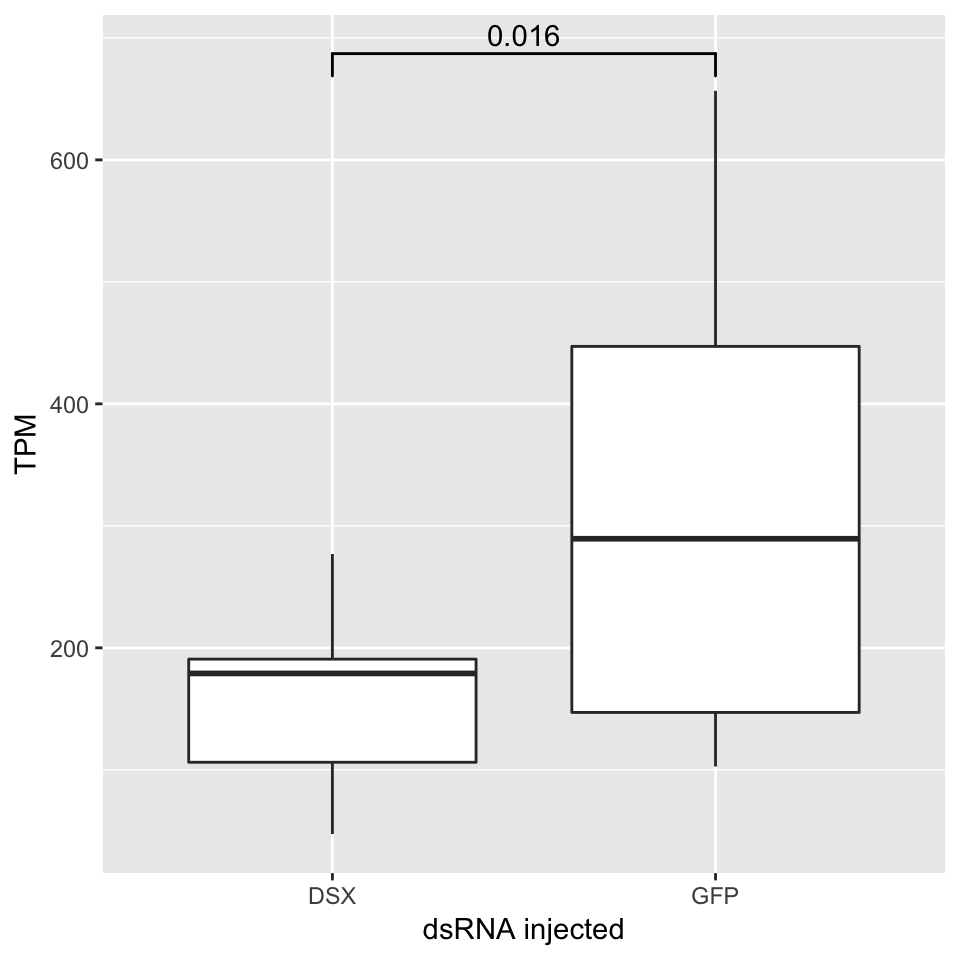

```r
vgTest <- function(a,b) return(data.frame(p.value = de.tgw$table %>% filter(gene_id  == "Vg") %>% .$PValue))
data.frame(tpm = t(subset(tpm, gene_id == "Vg")[,as.character(treatments$sample)]) , trt = treatments$treatment) %>% ggplot(aes(trt,tpm))+geom_boxplot() + geom_signif(comparisons = list(c("DSX", "GFP")), test = "vgTest") + xlab("dsRNA injected")+ylab("TPM")
```

#### Isoform-specific expression using EdgeR

We are using single-end reads, so we don’t expect much power to distinguish isoforms, but is is worth checking.

```r
dsxIsoforms <- tibble(isoform_id = c("NM_001111255.1", "NM_001134935.1", "NM_001134936.1", "NR_024131.1" ,"XM_006560013.2"), description = c("M", "F2", "B", "RNA", "X1"))
isoforms <- read_csv("data/isoforms.csv") %>% filter(! grepl("ERCC", isoform_id))
cdsIso <- DGEList( isoforms[, treatments$sample], group = treatments$treatment)
cdsIso <- calcNormFactors( cdsIso)
cdsIso <- estimateDisp( cdsIso, design)
deIso.tgw <- exactTest( cdsIso , pair = c( "DSX" , "GFP" ) )
deIso.tgw$table$isoform_id <- isoforms$isoform_id
kable(deIso.tgw$table %>% filter(isoform_id %in% dsxIsoforms$isoform_id) %>% left_join(dsxIsoforms, by = "isoform_id"))
```

| logFC | logCPM | PValue | isoform_id | description |
| --- | --- | --- | --- | --- |
| 0.4836133 | 1.025245 | 0.3808945 | NR_024131.1 | RNA |
| 0.7477926 | 6.871002 | 0.0522470 | XM_006560013.2 | X1 |
| 1.4145332 | -1.208466 | 0.3678700 | NM_001134936.1 | B |
| 1.4269961 | -2.455635 | 0.4267905 | NM_001134935.1 | F2 |
| 0.0000000 | -2.555809 | 1.0000000 | NM_001111255.1 | M |

Actually, the X1 isoform, the one we actually knocked down is significantly lower in the *Dsx* RNAi-treated bees (using a one-tailed test).

### Kallisto/Sleuth analysis

```r
treatments <- treatments %>% mutate(path = paste0("./data/kallisto/", sample))
t2g <- read_tsv("data/g2i.tsv", col_names=c('target_id','gene_id', 'description'))
so <- sleuth_prep(treatments, target_mapping = t2g, aggregation_column = 'gene_id')
so <- sleuth_fit(so, ~treatment, 'full')
so <- sleuth_fit(so, ~1, 'reduced')
so <- sleuth_lrt(so, 'reduced', 'full')
sleuth_table <- sleuth_results(so, 'reduced:full', 'lrt', show_all = FALSE)
saveRDS(sleuth_table, "data/sleuth_table.rds")
```

```r
sleuth_table %>% filter(target_id == "Dsx")
```

```
##   target_id test_stat       pval      qval      rss  sigma_sq    tech_var
## 1       Dsx   3.87193 0.04910003 0.6887556 8.863661 0.4652597 0.001248802
##   mean_obs   var_obs sigma_sq_pmax smooth_sigma_sq final_sigma_sq
## 1 5.986005 0.4665085     0.4652597       0.1337446      0.4652597
##   degrees_free
## 1            1
```

Both quantification approaches provide the same result, *Dsx* is upregulated in the control bees, and so is *Vg* (as predicted).

## Weighted gene co-expression analysis

We are interested in understanding the netwoks of genes co-expressed with *Dsx* in honey bees, and to checke whether this network is associated with RNAi treatment.

```r
expDat <- as.data.frame(t(tpm %>% filter(! grepl("ERCC", gene_id)) %>% dplyr::select(-gene_id)))
colnames(expDat) <- tpm %>% filter(! grepl("ERCC", gene_id)) %>% .$gene_id
expDat <- expDat[as.character(treatments$sample),] # re-arrange to match treatments vector
pickSoftThreshold(expDat, RsquaredCut = 0.8, networkType = "unsigned")$powerEstimate
```

```
##    Power SFT.R.sq  slope truncated.R.sq mean.k. median.k. max.k.
## 1      1    0.645  8.410          0.956  3900.0    3990.0   6160
## 2      2    0.163  0.263          0.602  1770.0    1790.0   3600
## 3      3    0.175 -0.348          0.817   985.0     970.0   2380
## 4      4    0.469 -0.672          0.845   620.0     579.0   1730
## 5      5    0.598 -0.824          0.866   423.0     370.0   1330
## 6      6    0.687 -0.902          0.893   305.0     249.0   1050
## 7      7    0.733 -0.947          0.896   230.0     173.0    857
## 8      8    0.762 -0.995          0.894   179.0     124.0    721
## 9      9    0.769 -1.050          0.876   142.0      91.3    623
## 10    10    0.776 -1.090          0.866   116.0      68.3    545
## 11    12    0.889 -1.090          0.945    80.7      40.2    431
## 12    14    0.898 -1.150          0.952    59.1      24.9    362
## 13    16    0.896 -1.230          0.954    44.8      16.1    318
## 14    18    0.894 -1.290          0.955    35.1      10.7    283
## 15    20    0.910 -1.300          0.971    28.1       7.4    255
```

```
## [1] 12
```

```r
SoftPower = 12
```

We’ll pick soft power 12, which is over the 0.8 threshold.

```r
net <- blockwiseModules(expDat, power = SoftPower,
TOMType = "unsigned", minModuleSize = 30,
reassignThreshold = 0, mergeCutHeight = 0.25,
numericLabels = TRUE, pamRespectsDendro = FALSE,
saveTOMs = FALSE,
verbose = 3, maxBlockSize = 15000)
saveRDS(net, "data/net.rds")
```

```r
MEs0 <- moduleEigengenes(expDat, net$colors)$eigengenes
MEs <- orderMEs(MEs0)
modNames <- substring(names(MEs), 3)
moduleTraitCor <- cor(MEs, as.numeric(gsub("GFP",0,gsub("DSX",1,treatments$treatment))), method = "spearman");
moduleTraitPvalue <- corPvalueStudent(moduleTraitCor, 20)
(DsxModule <- net$colors[which(colnames(expDat) == "Dsx")])
```

```
## [1] 6
```

```r
table(net$colors) %>% kable("html", caption = "Number of genes in the different modules. The Dsx-repsonsive module is highlighted", col.names
 = c("Module", "Number of genes")) %>% kable_styling() %>% row_spec(DsxModule+1, background = "red") %>% scroll_box(height = "200px")
```

Number of genes in the different modules. The Dsx-repsonsive module is highlighted

| Module | Number of genes |
| --- | --- |
| 0 | 544 |
| 1 | 3314 |
| 2 | 1786 |
| 3 | 1535 |
| 4 | 1381 |
| 5 | 983 |
| 6 | 967 |
| 7 | 732 |
| 8 | 682 |
| 9 | 342 |
| 10 | 238 |
| 11 | 155 |
| 12 | 146 |
| 13 | 146 |
| 14 | 107 |
| 15 | 96 |
| 16 | 94 |
| 17 | 92 |
| 18 | 83 |
| 19 | 75 |
| 20 | 62 |
| 21 | 54 |
| 22 | 54 |
| 23 | 52 |
| 24 | 51 |
| 25 | 40 |

### Exploring the *Dsx*-containing module

#### Intramodular connectivity and gene significance

```r
Alldegrees <- intramodularConnectivity.fromExpr(expDat, net$colors, power = SoftPower)
```

```
##  softConnectivity: FYI: connecitivty of genes with less than 7 valid samples will be returned as NA.
##  ..calculating connectivities..
```

```r
rownames(Alldegrees) <- colnames(expDat)
geneModuleMembership <- as.data.frame(cor(expDat, MEs, use = "p"));
Alldegrees["Dsx",]
```

```
##       kTotal  kWithin     kOut     kDiff
## Dsx 76.54159 32.44871 44.09288 -11.64418
```

```r
DsxModuleGenes <- colnames(expDat)[net$colors == DsxModule]
connectivityDsxModule <- data.frame(kWithin = Alldegrees[DsxModuleGenes,"kWithin"], gene_id = rownames(Alldegrees[DsxModuleGenes,]), moduleMembership = geneModuleMembership[DsxModuleGenes, paste0("ME",DsxModule)]) %>% left_join(de.tgw$table, by = "gene_id")
dsxModuleGenes <- descriptions %>% filter(gene_id %in% colnames(expDat)[net$colors == DsxModule] ) %>% left_join(de.tgw$table, by = "gene_id") %>% left_join(connectivityDsxModule %>% dplyr::select(gene_id, kWithin), by="gene_id") %>% dplyr::select(gene = gene_id, description = description.x, logFC, kWithin, logCPM) %>% arrange(desc(logFC))
highligh <- which(dsxModuleGenes$gene %in% c("Vg", "Dsx", "Dnmt3"))
```

##### Table S1. Genes in the *Dsx*-responsive module

In addition to *Dsx*, this module contains *Vg*, as predicted. It also contains the DNA methyltransferase *Dnmt3*, which has been shown to be involved in queen/worker differentiation during development.

###### Sorted by logFC

Genes in the Dsx-containing module. Higher values of logFC correspond to greater expression in control bees. Genes known to be assciated with reproductive division of labor are highlighted in red.

| gene | description | logFC | kWithin | logCPM |
| --- | --- | --- | --- | --- |
| LOC102655871 | uncharacterized HTH-type transcriptional regulator HI_1364-like | 4.1278771 | 30.7563014 | -1.9771818 |
| LOC727487 | selenium-binding protein 1-A-like | 4.0680932 | 53.9970165 | 1.7454831 |
| LOC107965906 | probable serine/threonine-protein kinase DDB_G0282963 | 3.9192460 | 42.5831186 | -2.0428285 |
| LOC102653653 | uncharacterized LOC102653653 | 3.6357315 | 65.0384409 | 1.0357067 |
| LOC551816 | SH3 domain-binding protein 5-like | 3.5434360 | 44.8587257 | -2.1562394 |
| LOC107965634 | uncharacterized LOC107965634 | 3.2434560 | 1.0720439 | -2.2306041 |
| LOC107965444 | uncharacterized LOC107965444 | 2.9796074 | 5.4945517 | -2.0426669 |
| LOC107964215 | uncharacterized LOC107964215 | 2.9594147 | 57.2450646 | -2.2906962 |
| LOC100577416 | peptide chain release factor 2-like | 2.5773551 | 29.1640097 | -2.1687064 |
| LOC107964975 | uncharacterized LOC107964975 | 2.4179152 | 28.5998615 | 1.4682996 |
| LOC107964188 | uncharacterized LOC107964188 | 2.1740449 | 14.4784659 | -2.2627623 |
| LOC102653914 | uncharacterized LOC102653914 | 2.1568864 | 3.0378980 | -2.2614029 |
| Mir9891 | microRNA 9891 | 2.1507545 | 64.1643044 | -2.4172331 |
| LOC100576244 | aryl-phospho-beta-D-glucosidase BglH-like | 2.1504175 | 27.1237917 | -2.4172703 |
| LOC726094 | uncharacterized LOC726094 | 2.1060000 | 13.4500606 | -2.4222344 |
| LOC102656707 | uncharacterized LOC102656707 | 2.0611603 | 7.5368836 | -0.4537934 |
| LOC102654203 | uncharacterized LOC102654203 | 2.0457756 | 57.2152537 | -2.4294918 |
| LOC107965758 | uncharacterized LOC107965758 | 2.0306263 | 3.7936235 | -2.4306537 |
| LOC102653912 | uncharacterized LOC102653912 | 2.0100056 | 6.7921854 | -1.0552727 |
| LOC102655698 | uncharacterized LOC102655698 | 2.0084339 | 2.4848101 | -1.7860302 |
| LOC410776 | protein 60A | 1.7940451 | 21.7286992 | 0.0398473 |
| LOC107966094 | uncharacterized LOC107966094 | 1.7859992 | 50.7954873 | -2.4568178 |
| LOC100576248 | uncharacterized LOC100576248 | 1.7608590 | 18.6020102 | -1.0608890 |
| LOC102655972 | uncharacterized LOC102655972 | 1.7363988 | 44.4304672 | -2.3312220 |
| LOC409787 | paramyosin, long form-like | 1.7318902 | 30.6657920 | 8.3189935 |
| LOC726654 | T-box protein H15-like | 1.7155406 | 33.0219519 | -1.9118649 |
| LOC102654436 | uncharacterized LOC102654436 | 1.7093575 | 8.4270840 | -0.9772877 |
| LOC107965409 | uncharacterized LOC107965409 | 1.6959910 | 1.8622506 | -2.1067742 |
| LOC100576524 | transmembrane protein 94-like | 1.6730918 | 3.4739230 | -0.4806128 |
| LOC102654518 | uncharacterized LOC102654518 | 1.6684932 | 21.9821375 | 0.6872862 |

[output cut: 937 more lines]

###### Sorted by intra-modular connectivity

Genes in the Dsx-containing module. Higher values of logFC correspond to greater expression in control bees. Genes known to be assciated with reproductive division of labor are highlighted in red.

| gene | description | logFC | kWithin | logCPM |
| --- | --- | --- | --- | --- |
| LOC411083 | sodium/potassium-transporting ATPase subunit alpha | 0.3148439 | 88.4482596 | 8.1161213 |
| LOC409536 | arginine-glutamic acid dipeptide repeats protein | 0.6952491 | 83.9081864 | 6.0450926 |
| LOC727455 | UBA-like domain-containing protein 2 | 0.4078972 | 83.7403545 | 6.8630571 |
| LOC726486 | uncharacterized LOC726486 | 0.4362861 | 83.4369053 | 7.6807720 |
| LOC102655479 | apoptosis-stimulating of p53 protein 2-like | 0.6088103 | 82.7003848 | 4.9305540 |
| LOC408884 | transcription factor SOX-5 | 0.7159568 | 82.1124845 | 5.2529432 |
| LOC102654353 | alpha-(1,3)-fucosyltransferase C | 0.6215493 | 81.6287785 | 5.9300833 |
| LOC552545 | division abnormally delayed protein | 0.6875360 | 80.8873113 | 5.1706967 |
| LOC725732 | uncharacterized LOC725732 | 0.8772066 | 78.4888677 | 7.0120854 |
| LOC409759 | serine-rich adhesin for platelets-like | 0.6018953 | 78.3571226 | 3.5862933 |
| LOC408429 | tensin-1 | 0.9339438 | 77.3130129 | 9.0999733 |
| LOC409658 | uncharacterized LOC409658 | 0.5192188 | 76.1660094 | 4.9952055 |
| LOC550799 | DAZ-associated protein 2-like | 0.5119810 | 75.9292080 | 8.7922817 |
| LOC408685 | MAP7 domain-containing protein 1 | 0.2362098 | 74.8692681 | 9.7095780 |
| LOC410637 | nuclear receptor coactivator 3-like | 0.6984678 | 74.7211359 | 6.4612596 |
| LOC412795 | protocadherin-15 | 0.6734834 | 73.3225167 | 3.4116108 |
| LOC726283 | neuronal calcium sensor 2 | 1.0201855 | 72.7224369 | 2.0729008 |
| LOC410423 | uncharacterized LOC410423 | 0.2252604 | 72.6915153 | 5.7309500 |
| LOC552466 | filamin-A-like | 0.5412431 | 72.2949842 | 7.5459191 |
| LOC100578159 | zinc finger matrin-type protein CG9776-like | 0.6347480 | 71.7926601 | 6.1907512 |
| LOC413427 | uncharacterized LOC413427 | 0.3196507 | 71.7486957 | 3.6461459 |
| Mir3730 | microRNA 3730 | 0.8425770 | 70.8150756 | -0.1852727 |
| LOC724563 | uncharacterized LOC724563 | 0.3522561 | 70.8058337 | 3.0278921 |
| LOC100577486 | uncharacterized LOC100577486 | 0.6799707 | 69.8768644 | 4.5345130 |
| LOC107965146 | uncharacterized LOC107965146 | 0.4933416 | 69.6823200 | 3.0745884 |
| LOC100576233 | titin-like | 0.6802412 | 69.4193954 | 5.7300651 |
| LOC411365 | beta-1,4-N-acetylgalactosaminyltransferase bre-4 | 0.8153892 | 69.3538808 | 5.4275751 |
| LOC410802 | microphthalmia-associated transcription factor | 0.1809516 | 69.3244563 | 5.1723108 |
| LOC411157 | fat-like cadherin-related tumor suppressor homolog | 0.7608550 | 69.1532771 | 5.5387394 |
| LOC410487 | uncharacterized LOC410487 | 0.2530178 | 68.9948979 | 5.2019419 |

[output cut: 937 more lines]

```r
with(connectivityDsxModule, cor.test(logFC, kWithin, method = "s"))
```

```
##
##  Spearman's rank correlation rho
##
## data:  logFC and kWithin
## S = 95677000, p-value < 2.2e-16
## alternative hypothesis: true rho is not equal to 0
## sample estimates:
##       rho
## 0.3651401
```

```r
interestingGenes <- c("Dsx", "Vg")
p <-ggplot(connectivityDsxModule, aes(logFC, kWithin))+geom_point(alpha=0.1) +geom_point(data=subset(connectivityDsxModule, gene_id %in% interestingGenes), colour="red")+theme_bw()+geom_text(data=subset(connectivityDsxModule, gene_id %in% interestingGenes), aes(label = gene_id), nudge_x=.2)+stat_smooth(method="lm", color="blue", se = F)
ggsave("Dsx module.pdf", width = 5, height = 5)
```

##### Figure S1. Module membership *vs.* treatment effect

Hover over the points to reveal gene names. There is a significant correlation between connectivity within this module and log-fold change as a result of RNAi treatment. In other words, this is a *Dsx*-responsive module.

[interactive chart not shown]

#### GO term enrichment

```r
go <- read_tsv("data/go.tsv", col_types = cols()) %>% mutate(evidence = "ISS") %>% dplyr::select(GO=go, evidence,gene=gene_id)
universe <- unique(go$gene)
goFrame <- GOFrame(as.data.frame(go %>% dplyr::filter(gene %in% universe)), organism="Apis melliefera")
goAllFrame <- GOAllFrame(goFrame)
gsc <- GeneSetCollection(goAllFrame, setType = GOCollection())

DsxModuleGo <- hyperGTest(GSEAGOHyperGParams(name = "enriched in Dsx module",
    geneSetCollection=gsc,geneIds = intersect(dsxModuleGenes$gene,universe), universeGeneIds=universe, ontology = "BP",pvalueCutoff = 0.05,conditional = FALSE,testDirection = "over"))
```

###### Table S2. GO term enrichmed in *Dsx*-responsive module

```r
summary(DsxModuleGo) %>% kable("html", digits = 3) %>% kable_styling() %>%  kable_styling(bootstrap_options = c("striped", "hover", "condensed", "responsive"), full_width = T) %>% scroll_box(height = "400px")
```

| GOBPID | Pvalue | OddsRatio | ExpCount | Count | Size | Term |
| --- | --- | --- | --- | --- | --- | --- |
| GO:0050789 | 0.000 | 2.271 | 50.719 | 83 | 683 | regulation of biological process |
| GO:0050794 | 0.000 | 2.267 | 49.234 | 81 | 663 | regulation of cellular process |
| GO:0065007 | 0.000 | 2.223 | 53.021 | 85 | 714 | biological regulation |
| GO:1903506 | 0.000 | 2.482 | 14.035 | 29 | 189 | regulation of nucleic acid-templated transcription |
| GO:2001141 | 0.000 | 2.482 | 14.035 | 29 | 189 | regulation of RNA biosynthetic process |
| GO:0006355 | 0.000 | 2.482 | 14.035 | 29 | 189 | regulation of transcription, DNA-templated |
| GO:0051252 | 0.000 | 2.466 | 14.109 | 29 | 190 | regulation of RNA metabolic process |
| GO:0019219 | 0.000 | 2.402 | 14.406 | 29 | 194 | regulation of nucleobase-containing compound metabolic process |
| GO:0080090 | 0.000 | 2.279 | 16.708 | 32 | 225 | regulation of primary metabolic process |
| GO:0010556 | 0.000 | 2.318 | 15.372 | 30 | 207 | regulation of macromolecule biosynthetic process |
| GO:0031326 | 0.000 | 2.318 | 15.372 | 30 | 207 | regulation of cellular biosynthetic process |
| GO:2000112 | 0.000 | 2.318 | 15.372 | 30 | 207 | regulation of cellular macromolecule biosynthetic process |
| GO:0009889 | 0.000 | 2.318 | 15.372 | 30 | 207 | regulation of biosynthetic process |
| GO:0051171 | 0.000 | 2.276 | 15.594 | 30 | 210 | regulation of nitrogen compound metabolic process |
| GO:0023052 | 0.000 | 1.946 | 26.808 | 44 | 361 | signaling |
| GO:0031323 | 0.000 | 2.170 | 16.783 | 31 | 226 | regulation of cellular metabolic process |
| GO:0060255 | 0.000 | 2.134 | 17.599 | 32 | 237 | regulation of macromolecule metabolic process |
| GO:0010468 | 0.001 | 2.159 | 16.263 | 30 | 219 | regulation of gene expression |
| GO:0044700 | 0.001 | 1.910 | 26.511 | 43 | 357 | single organism signaling |
| GO:0007154 | 0.001 | 1.903 | 26.585 | 43 | 358 | cell communication |
| GO:0019222 | 0.001 | 2.068 | 18.045 | 32 | 243 | regulation of metabolic process |
| GO:0007165 | 0.001 | 1.831 | 25.991 | 41 | 350 | signal transduction |
| GO:0007050 | 0.002 | 37.974 | 0.297 | 3 | 4 | cell cycle arrest |
| GO:0007155 | 0.002 | 3.405 | 3.564 | 10 | 48 | cell adhesion |
| GO:0022610 | 0.002 | 3.405 | 3.564 | 10 | 48 | biological adhesion |
| GO:0050896 | 0.003 | 1.646 | 35.793 | 51 | 482 | response to stimulus |
| GO:0009081 | 0.005 | Inf | 0.149 | 2 | 2 | branched-chain amino acid metabolic process |
| GO:0009082 | 0.005 | Inf | 0.149 | 2 | 2 | branched-chain amino acid biosynthetic process |
| GO:0016337 | 0.005 | Inf | 0.149 | 2 | 2 | single organismal cell-cell adhesion |
| GO:0098602 | 0.005 | Inf | 0.149 | 2 | 2 | single organism cell adhesion |
| GO:0098609 | 0.006 | 5.306 | 1.262 | 5 | 17 | cell-cell adhesion |
| GO:0097659 | 0.006 | 1.713 | 22.352 | 34 | 301 | nucleic acid-templated transcription |
| GO:0006351 | 0.006 | 1.713 | 22.352 | 34 | 301 | transcription, DNA-templated |
| GO:0032774 | 0.007 | 1.706 | 22.426 | 34 | 302 | RNA biosynthetic process |
| GO:0051716 | 0.009 | 1.577 | 32.229 | 45 | 434 | cellular response to stimulus |
| GO:0035556 | 0.010 | 1.822 | 14.703 | 24 | 198 | intracellular signal transduction |
| GO:0043543 | 0.011 | 9.482 | 0.520 | 3 | 7 | protein acylation |
| GO:0007264 | 0.014 | 2.001 | 8.911 | 16 | 120 | small GTPase mediated signal transduction |
| GO:0045216 | 0.016 | 25.183 | 0.223 | 2 | 3 | cell-cell junction organization |
| GO:0034329 | 0.016 | 25.183 | 0.223 | 2 | 3 | cell junction assembly |
| GO:0034330 | 0.016 | 25.183 | 0.223 | 2 | 3 | cell junction organization |
| GO:0008285 | 0.016 | 25.183 | 0.223 | 2 | 3 | negative regulation of cell proliferation |
| GO:0045595 | 0.016 | 25.183 | 0.223 | 2 | 3 | regulation of cell differentiation |
| GO:0002520 | 0.016 | 25.183 | 0.223 | 2 | 3 | immune system development |
| GO:0048534 | 0.016 | 25.183 | 0.223 | 2 | 3 | hematopoietic or lymphoid organ development |
| GO:0030097 | 0.016 | 25.183 | 0.223 | 2 | 3 | hemopoiesis |
| GO:0050793 | 0.017 | 7.582 | 0.594 | 3 | 8 | regulation of developmental process |
| GO:0048513 | 0.017 | 7.582 | 0.594 | 3 | 8 | animal organ development |
| GO:0048731 | 0.021 | 4.608 | 1.114 | 4 | 15 | system development |
| GO:0032501 | 0.023 | 2.089 | 6.386 | 12 | 86 | multicellular organismal process |
| GO:0042981 | 0.024 | 6.316 | 0.668 | 3 | 9 | regulation of apoptotic process |
| GO:0043067 | 0.024 | 6.316 | 0.668 | 3 | 9 | regulation of programmed cell death |
| GO:0051239 | 0.024 | 6.316 | 0.668 | 3 | 9 | regulation of multicellular organismal process |
| GO:0010941 | 0.024 | 6.316 | 0.668 | 3 | 9 | regulation of cell death |
| GO:0009966 | 0.025 | 2.353 | 4.307 | 9 | 58 | regulation of signal transduction |
| GO:0048523 | 0.029 | 2.626 | 3.045 | 7 | 41 | negative regulation of cellular process |
| GO:0001505 | 0.030 | 12.586 | 0.297 | 2 | 4 | regulation of neurotransmitter levels |
| GO:0008283 | 0.030 | 12.586 | 0.297 | 2 | 4 | cell proliferation |
| GO:0042127 | 0.030 | 12.586 | 0.297 | 2 | 4 | regulation of cell proliferation |
| GO:0048518 | 0.032 | 2.376 | 3.787 | 8 | 51 | positive regulation of biological process |
| GO:0016569 | 0.033 | 3.896 | 1.262 | 4 | 17 | covalent chromatin modification |
| GO:0016570 | 0.033 | 3.896 | 1.262 | 4 | 17 | histone modification |
| GO:0010646 | 0.034 | 2.214 | 4.530 | 9 | 61 | regulation of cell communication |
| GO:0023051 | 0.037 | 2.172 | 4.604 | 9 | 62 | regulation of signaling |
| GO:0048583 | 0.037 | 2.172 | 4.604 | 9 | 62 | regulation of response to stimulus |
| GO:1902531 | 0.041 | 2.410 | 3.267 | 7 | 44 | regulation of intracellular signal transduction |
| GO:0045786 | 0.043 | 4.733 | 0.817 | 3 | 11 | negative regulation of cell cycle |
| GO:0006325 | 0.046 | 2.541 | 2.673 | 6 | 36 | chromatin organization |
| GO:2000026 | 0.047 | 8.387 | 0.371 | 2 | 5 | regulation of multicellular organismal development |
| GO:0016573 | 0.047 | 8.387 | 0.371 | 2 | 5 | histone acetylation |
| GO:0006836 | 0.047 | 8.387 | 0.371 | 2 | 5 | neurotransmitter transport |

#### Visualizing genes connected to Dsx.

```r
maxTopGenes <- 30
DsxConnections <- data.frame(cor = cor(expDat[,net$colors == DsxModule], expDat[, "Dsx"]), annot = descriptions$description[match(colnames(expDat[,net$colors == DsxModule]), descriptions$gene_id)])
topGenes <- rownames(DsxConnections)[order(DsxConnections$cor, decreasing = T)[1:maxTopGenes]]
ADJ <- abs(cor(expDat, use="p"))^SoftPower
TOM  <- TOMsimilarity(ADJ)
modTOM <- TOM[net$colors == DsxModule, net$colors == DsxModule]
dimnames(modTOM) = list(DsxModuleGenes, DsxModuleGenes)
saveRDS(modTOM, "data/modTOM.rds")
```

##### Figure S2. Interactive network of *Dsx*-connected genes

This network shows the 30 genes most highly connected to _Dsx, with edge weights proportional to the strength of the connection, and node areas to log counts per million.

[interactive chart not shown]